# Stroke Prediction

## **3. Exploratory Data Analysis**

### **3.1 Analysing Missing Values**

A Missigness map is plotted which will show values which are missing in the data. Color red denotes value presence and blue will denotes the missing patches.

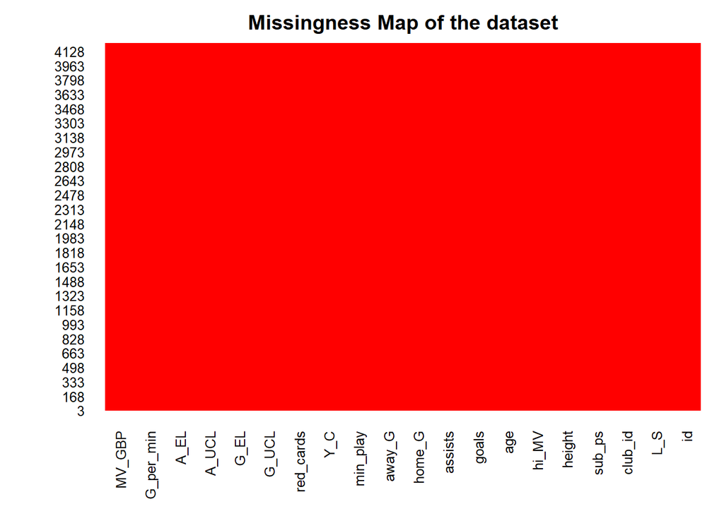

```r
missmap(market_value1, col = c("blue", "red"), legend = F, main = ("Missingness Map of the dataset"))
```

It can be seen that no data is being missed from the market_value1 dataset.

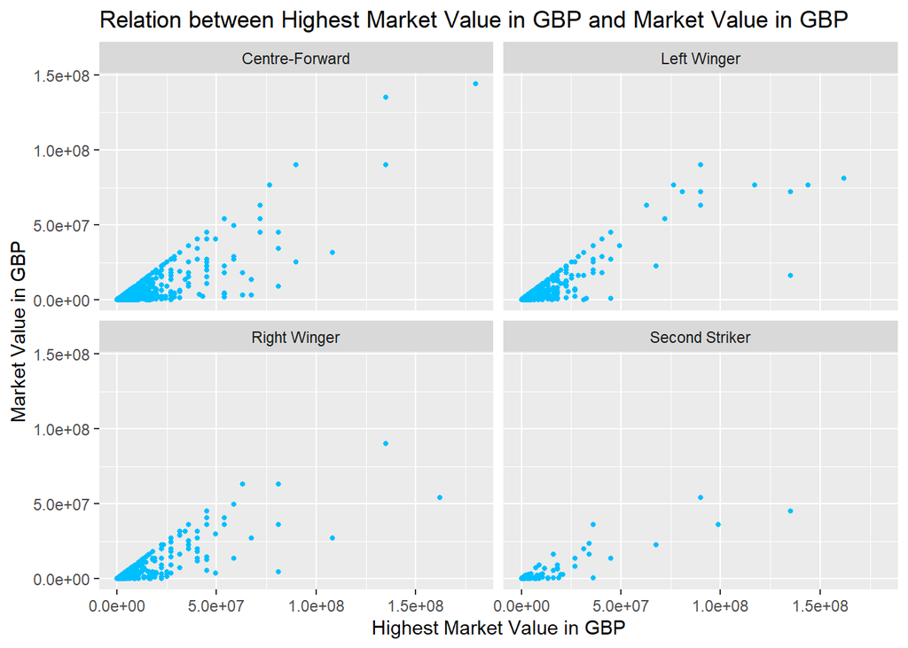

```r
ggplot(market_value1, aes(x = hi_MV, y = MV_GBP)) +
  ggtitle("Relation between Highest Market Value in GBP and Market Value in GBP") +
  geom_point(colour = "deepskyblue", size = 1) +
  facet_wrap(~sub_ps)+
  labs(x = "Highest Market Value in GBP", y = "Market Value in GBP")
```

```r
  #
```

### 3.2 Market Value VS Sub Position

```r
df = market_value1%>%
  filter(!is.na(sub_ps))%>%
  filter(!is.na(MV_GBP))%>%
  group_by(sub_ps)%>%
  summarise( min = min(MV_GBP), max = max(MV_GBP), Count = n(), Average = mean(MV_GBP))%>%
  arrange(desc(Count))%>%
  head(15)

  highchart()%>%
     hc_title(
    text = "Maximum, Average and Minimum Salary of the Players"
    ) %>%
    hc_subtitle(
    text = "From the graph, it is clear that player who plays in the center forward are paid highest fee."
    ) %>%
  hc_xAxis(categories = df$sub_ps)%>%
  hc_add_series(name = "Max Fee", data = df$max)%>%
    hc_add_series(name = "Average Fee", data = df$Average)%>%
    hc_add_series(name = "Min Fee", data = df$Count)%>%
  hc_chart(type = "column",
           options3d = list(enabled = TRUE, beta = 15, alpha = 15))
```

[interactive chart not shown]

### 3.3 Distribution of the Market Value in GBP

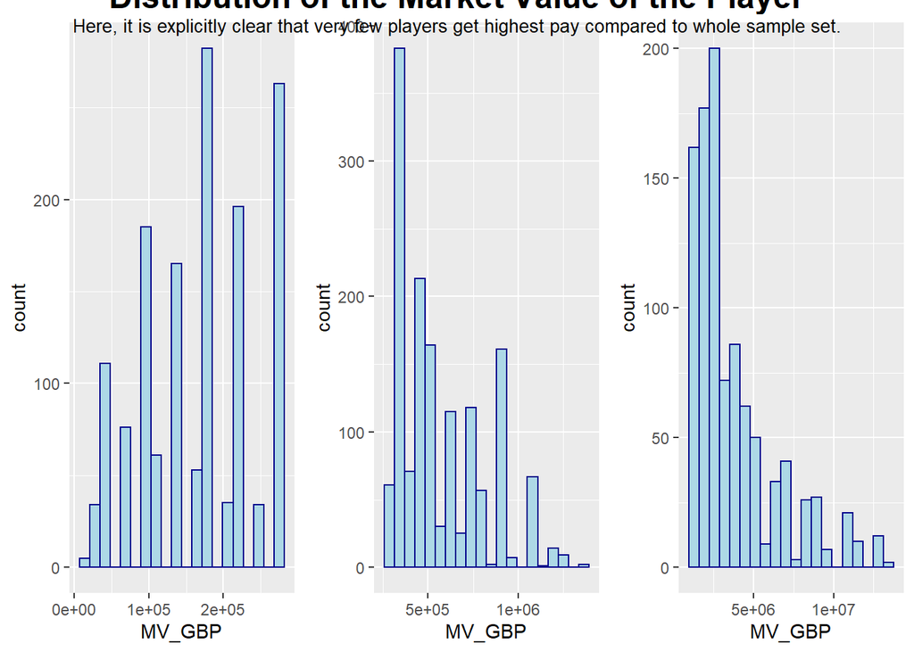

```r
hist_D <- market_value1[order(market_value1$MV_GBP),]

hist_1 <- hist_D[1:1500, ]
c1 = ggplot(data = hist_1, aes(x = MV_GBP)) + geom_histogram(color="darkblue", fill="lightblue",bins = 20)

hist_2 <- hist_D[1501:3000, ]
c2= ggplot(data = hist_2, aes(x = MV_GBP)) + geom_histogram(color="darkblue", fill="lightblue",bins = 20)

hist_3 <- hist_D[3001:4000, ]
c3= ggplot(data = hist_3, aes(x = MV_GBP)) + geom_histogram(color="darkblue", fill="lightblue",bins = 20)

tg <- textGrob("Distribution of the Market Value of the Player", gp = gpar(fontface = "bold", cex = 1.5))
sg <- textGrob('Here, it is explicitly clear that very few players get highest pay compared to whole sample set.', gp = gpar(fontsize = 10))

lt <- list(tg, sg)
heights <- do.call(unit.c, lapply(lt, function(.g) 1.5*grobHeight(.g)))
titles <- gtable::gtable_matrix('title',
                                grobs = matrix(lt, ncol=1),
                                widths = unit(1,'npc'),
                                heights = heights)


grid.arrange(c1,c2,c3, ncol= 3, top = titles)
```

### 3.4 Relation between Goals and Market Value in GBP

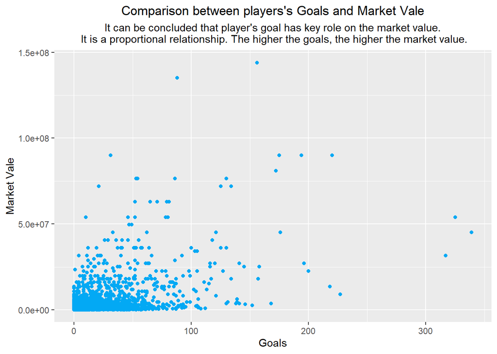

```r
ggplot(market_value1, aes(x = goals, y = MV_GBP)) +
  geom_point(colour = "#03A9F4") +
  labs(title = "Comparison between players's Goals and Market Vale",
       subtitle="It can be concluded that player's goal has key role on the market value.\n It is a proportional relationship. The higher the goals, the higher the market value.",
       x = "Goals", y = "Market Vale")+
  theme(plot.title=element_text(hjust=0.5),
        plot.subtitle=element_text(hjust=0.5))
```

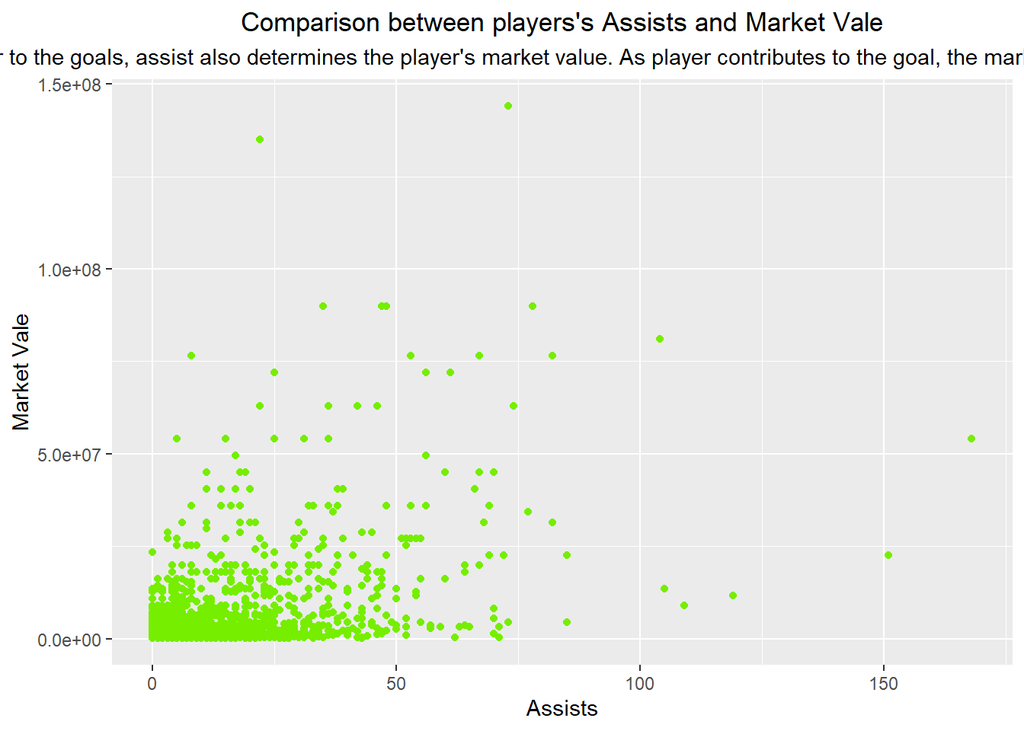

```r
ggplot(market_value1, aes(x = assists, y = MV_GBP)) +
  geom_point(colour = "chartreuse2") +
  labs(title = "Comparison between players's Assists and Market Vale",
       subtitle="Similar to the goals, assist also determines the player's market value. As player contributes to the goal, the market price goes up",
       x = "Assists", y = "Market Vale")+
  theme(plot.title=element_text(hjust=0.5),
        plot.subtitle=element_text(hjust=0.5))
```

### **3.6 Correlation Graph**

```r
market_value1$sub_ps <- as.numeric(factor(market_value1$sub_ps))- 1

dummy <- dummyVars(" ~ .", data=market_value1)

#performing one-hot encoding on data frame
final_df <- data.frame(predict(dummy, newdata=market_value1))

corr <- correlate(final_df)
```

```
##
## Correlation method: 'pearson'
## Missing treated using: 'pairwise.complete.obs'
```

```r
# Extract the correlation
corr %>%
  focus(MV_GBP)
```

| term | MV_GBP |
| --- | --- |
| id | 0.01769854 |
| L_S | 0.22831658 |
| club_id | -0.08953174 |
| sub_ps | 0.02890191 |
| height | 0.03417890 |
| hi_MV | 0.85273044 |
| age | 0.11206687 |
| goals | 0.53068719 |
| assists | 0.52254465 |
| home_G | 0.46293824 |

[output cut: 9 more lines]

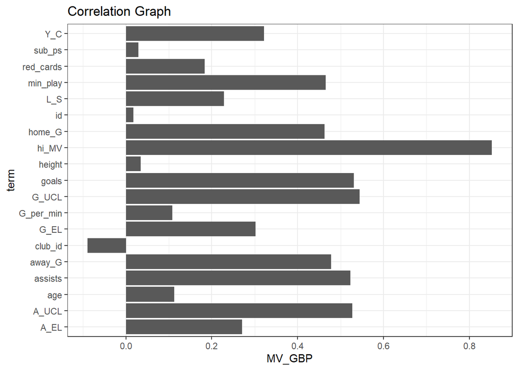

```r
corr %>%
  focus(MV_GBP) %>%
  mutate(rowname = reorder(term, MV_GBP)) %>%
  ggplot(aes(term, MV_GBP)) +
    geom_col() + coord_flip() +
  theme_bw()  + ggtitle("Correlation Graph")
```

```r
round(cor(subset(market_value1, select=c(hi_MV,goals, assists, Y_C, home_G,away_G, min_play, G_UCL, A_UCL, A_EL,MV_GBP ))),2)
```

```
##          hi_MV goals assists  Y_C home_G away_G min_play G_UCL A_UCL A_EL
## hi_MV     1.00  0.71    0.70 0.45   0.63   0.64     0.62  0.71  0.71 0.36
## goals     0.71  1.00    0.81 0.69   0.86   0.85     0.87  0.69  0.58 0.45
## assists   0.70  0.81    1.00 0.69   0.88   0.88     0.89  0.59  0.66 0.53
## Y_C       0.45  0.69    0.69 1.00   0.80   0.79     0.82  0.30  0.34 0.41
## home_G    0.63  0.86    0.88 0.80   1.00   0.99     0.97  0.47  0.49 0.52
## away_G    0.64  0.85    0.88 0.79   0.99   1.00     0.97  0.47  0.48 0.51
## min_play  0.62  0.87    0.89 0.82   0.97   0.97     1.00  0.47  0.47 0.50
## G_UCL     0.71  0.69    0.59 0.30   0.47   0.47     0.47  1.00  0.81 0.21
## A_UCL     0.71  0.58    0.66 0.34   0.49   0.48     0.47  0.81  1.00 0.23
## A_EL      0.36  0.45    0.53 0.41   0.52   0.51     0.50  0.21  0.23 1.00
## MV_GBP    0.85  0.53    0.52 0.32   0.46   0.48     0.47  0.54  0.53 0.27
##          MV_GBP
## hi_MV      0.85
## goals      0.53
## assists    0.52
## Y_C        0.32
## home_G     0.46
## away_G     0.48
## min_play   0.47
## G_UCL      0.54
## A_UCL      0.53
## A_EL       0.27
## MV_GBP     1.00
```

From the correlation diagram and chart, it appears that data related to **hi_MV (Highest market value in GBP), goals, assists, Y_C (Yellow Cards_, home_G (Home goal), away_G (Away goal), min_play (Minutes played), G_UCL (Goals in UCL), A_UCL** **(Assists in UCL)**are the main correlated factor to estimate a player’s financial worth. So, these nine features are being considered for the rest of the process.

## 4. Metric Selection

Here, three metrics have been chosen for the model accuracy.

### **4.1 R-Squared**

R-Squared, also referred as the Coefficient of Determination, is a value ranging from 0 to 1 that reflects how well the regression line fits the data. R-Squared can be interpreted as the proportion of variation in the dependent variable explained by the model. The model will predict the dependent variable better if R-Squared is near to one or one hundred percent <sup>[3]</sup>.

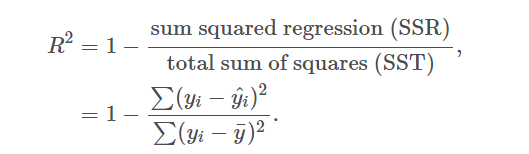

### 4.2 Adjusted R-squared

Adjusted R-squared is a variant of R-squared that accounts for the number of predictors in the model. When the new term improves the model more than can be expected by coincidence, the adjusted R-squared rises. It drops when a predictor improves the model by less than projected. The adjusted R-squared is normally positive rather than negative. It is never greater than R-squared.

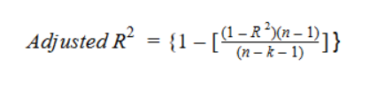

Here, n signifies the number of data points in the dataset, k represents the number of independent variables, and R signifies the R-squared values of the model <sup>[4]</sup>.

### 4.3 **F-Test**

The F-Test of overall significance in regression is used to test if a linear regression model matches a dataset better than a model with no predictor variables.

The F-Test of overall significance supports the following two hypotheses:

**Null hypothesis (H0) :** The model with no predictor variables (also referred to as an intercept-only model) fits the data and the regression model.

**Alternative hypothesis (HA) :**The regression model outperforms the intercept-only model in terms of data fit.

When a regression model has been fit to a dataset,a regression table will be created containing the F-statistic and the matching p-value for that F-statistic.

If the p-value is smaller than the significance threshold which has been chosen (*typical values include .01, .05, and .10*), it can be inferred that the regression model fits the data better than the intercept-only model.

## 5. Training and testing data sets

**70%** of the data will be used to train the model and the rest **30%** of the data will be utilized to evaluate its performance.

```r
n_train <- round(0.7 * nrow(market_value1))
train_indices <- sample(1:nrow(market_value1), n_train)
df_train <- market_value1[train_indices, ]
df_test <- market_value1[-train_indices, ]
```

## 6. Linear Regression Model

Here, it can be seen that only 9 features has been considered as they are more correlated to market value.

```r
lm.fit <- lm(MV_GBP ~ Y_C + goals + G_UCL+ away_G + home_G + assists + A_UCL+ min_play+hi_MV, data = df_train)

round(summary(lm.fit)$coefficients, 2)
```

```
##                Estimate Std. Error t value Pr(>|t|)
## (Intercept)   198835.33  104372.44    1.91     0.06
## Y_C           -33680.21   13954.49   -2.41     0.02
## goals         -18014.09    8674.63   -2.08     0.04
## G_UCL          68009.32   58629.10    1.16     0.25
## away_G         37313.30    5776.98    6.46     0.00
## home_G        -43829.69    4807.23   -9.12     0.00
## assists        29225.32   17288.77    1.69     0.09
## A_UCL       -1191300.61  113910.60  -10.46     0.00
## min_play         271.90      86.26    3.15     0.00
## hi_MV              0.63       0.01   65.28     0.00
```

```r
cat('R-Squared:', round(summary(lm.fit)$r.sq, 2),'   ', 'Adjusted R^2:', round(summary(lm.fit)$adj.r.sq, 2),'   ', 'F-Test:', round(summary(lm.fit)$f, 2))
```

```
## R-Squared: 0.75     Adjusted R^2: 0.75     F-Test: 968.18 9 2943
```

```r
lm.fit <- lm(MV_GBP ~  goals + G_UCL+ away_G + home_G + assists + A_UCL+ min_play+hi_MV, data = df_train)

round(summary(lm.fit)$coefficients, 2)
```

```
##                Estimate Std. Error t value Pr(>|t|)
## (Intercept)   180292.72  104174.58    1.73     0.08
## goals         -18042.46    8681.73   -2.08     0.04
## G_UCL          85114.55   58246.86    1.46     0.14
## away_G         38055.17    5773.52    6.59     0.00
## home_G        -44413.00    4805.08   -9.24     0.00
## assists        33261.63   17221.79    1.93     0.05
## A_UCL       -1210101.97  113737.03  -10.64     0.00
## min_play         203.90      81.60    2.50     0.01
## hi_MV              0.64       0.01   65.46     0.00
```

```r
cat('R-Squared:', round(summary(lm.fit)$r.sq, 2),'Adjusted R^2:', round(summary(lm.fit)$adj.r.sq, 2),'   ', 'F-Test:', round(summary(lm.fit)$f, 2))
```

```
## R-Squared: 0.75 Adjusted R^2: 0.75     F-Test: 1086.69 8 2944
```

After dropping the Yellow Card (Y_C), the Adjusted R^2 stayed the same while the F-Statistic greatly increased. The model is now simpler.

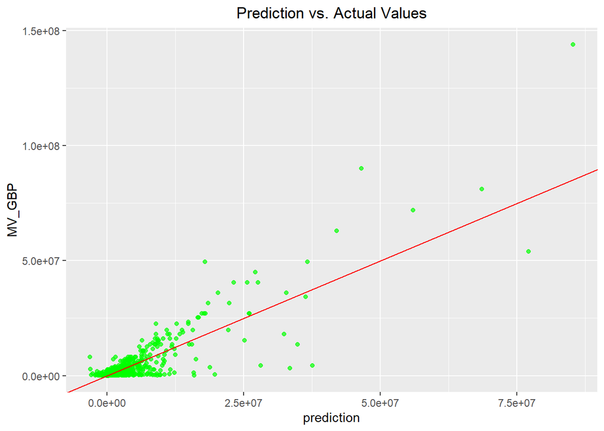

```r
df_test$prediction <- predict(lm.fit, newdata = df_test)
ggplot(df_test, aes(x = prediction, y = MV_GBP)) +
  geom_point(color = "green", alpha = 0.7) +
  geom_abline(color = "red") +
  ggtitle("Prediction vs. Actual Values")+
  theme(plot.title = element_text(hjust = 0.5))
```

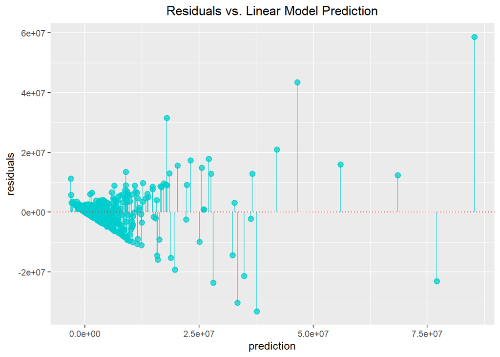

```r
df_test$residuals <- df_test$MV_GBP - df_test$prediction

ggplot(data = df_test, aes(x = prediction, y = residuals)) +
  geom_pointrange(aes(ymin = 0, ymax = residuals), color = "cyan3", alpha = 0.7) +
  geom_hline(yintercept = 0, linetype = 3, color = "red") +
  ggtitle("Residuals vs. Linear Model Prediction")+
  theme(plot.title = element_text(hjust = 0.5))
```

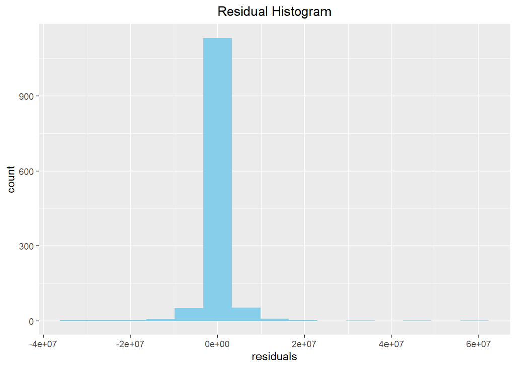

```r
ggplot(df_test, aes(x = residuals)) +
  geom_histogram(bins = 15, fill = "skyblue") +
  ggtitle("Residual Histogram")+
  theme(plot.title = element_text(hjust = 0.5))
```

The residuals are heavily concentrated around 0, which is a good sign the model is accurate.

## 8. Reference

[1] Ezzeddine, M. (2020). *Pricing football transfers : determinants, inflation, sustainability, and market impact : finance, economics, and machine learning approaches* [Doctoral Dissertation]. https://tel.archives-ouvertes.fr/tel-03171642

[2] UEFA.com. (2021, October 18). *Champions League Fantasy Football price changes – who has risen in value?* UEFA.com. https://www.uefa.com/uefachampionsleague/news/026e-136e4fd0c1e7-7ed92dcff837-1000--fantasy-price-changes/

[3] Investopedia. (2019). *What is the Difference Between R-Squared and Adjusted R-Squared?* Investopedia. https://www.investopedia.com/ask/answers/012615/whats-difference-between-rsquared-and-adjusted-rsquared.asp

[4] aniruddha. (2020, July 7). *Difference Between R-Squared and Adjusted R-Squared*. Analytics Vidhya. https://www.analyticsvidhya.com/blog/2020/07/difference-between-r-squared-and-adjusted-r-squared/#h2_2

[5] Choueiry, G. (2020, March). *Understand the F-statistic in Linear Regression – Quantifying Health*. Quantifying Health. https://quantifyinghealth.com/f-statistic-in-linear-regression/

[6] Zach. (2019, March 26). *A Simple Guide to Understanding the F-Test of Overall Significance in Regression*. Statology. https://www.statology.org/a-simple-guide-to-understanding-the-f-test-of-overall-significance-in-regression/